# finalProjectCervivalCancerML

Gitali Naim and Avital Abergel

8/17/2021

## Introduction:

Cervical cancer is among the 5 most common types of cancer in women worldwide. About 11,000 new cases of invasive cervical cancer are diagnosed each year in the U.S. However, the number of new cervical cancer cases has been declining steadily over the past decades. In the United States, cervical cancer mortality rates plunged by 74% from 1955 - 1992 thanks to increased screening and early detection with the Pap test. Using this new dataset, we’ll attempt to explore the phenomena and also identify the key predictors of cervical cancer. A more detailed explanation can be found at:https://www.kaggle.com/loveall/cervical-cancer-risk-classification

## Data Preparation:

We’ll start off by loading the libraries and reading the data, after that, we’ll take a glimpse of the dataset and it’s structure.

```r
# Load libraries:
library(wesanderson)
library(ggplot2)
library(dplyr)
library(DataExplorer)
library(rsample)
library(caret)
library(Boruta)
library(caTools)
library(e1071)
library(rpart)
library(randomForest)
library(Rtsne)
library(klaR)
library(psych)
library(MASS)
library(devtools)
library(adabag)
```

Note: A look at the data before and after manipulation can be seen in the supplemental

```r
# Load the dataset
cervicalCancerData <- read.csv("C:\\Users\\avita\\Downloads\\kag_risk_factors_cervical_cancer.csv")
# Checking the data size
dim(cervicalCancerData)
```

```
## [1] 858  36
```

```r
# Create a copy of the database. We will apply all needed changes on this copy.
newCervicalCancerData = cervicalCancerData
# Rename some of the column names
colnames(newCervicalCancerData)[6] <- "Smokes.years"
colnames(newCervicalCancerData)[7] <- "Smokes.packs.year"
colnames(newCervicalCancerData)[9] <- "Hormonal.Contraceptives.years"
colnames(newCervicalCancerData)[11] <- "IUD.years"
colnames(newCervicalCancerData)[13] <- "STDs.number"
colnames(newCervicalCancerData)[26] <- "STDs.Number.of.diagnosis"
colnames(newCervicalCancerData)[27] <- "STDs.Time.since.first.diagnosis"
colnames(newCervicalCancerData)[28] <- "STDs.Time.since.last.diagnosis"
```

## DATA MANIPULATION

We checked what columns need to be repaired. We identified columns that had incorrect values- a question mark appeared for women who chose not to answer certain questions. Then we converted the question marks to -1. This will allow us on the one hand to perform numerical operations, and on the other hand it will be obvious that this is a wrong observation.

```r
# Create all the function to identify all columns that need repair (If the sum values of cols is ? then we identify it). Then, fix missing values
cols = vector()
for (i in 1:ncol(newCervicalCancerData)){
  if (sum(newCervicalCancerData[,i] == "?") > 0){
    cols = c(cols,i)
  }
}
for (j in 1:length(cols)) {
  newCervicalCancerData[,cols[j]] = as.character(newCervicalCancerData[,cols[j]])
  newCervicalCancerData[which(newCervicalCancerData[,cols[j]] == "?"),cols[j]] = "-1.0"
  newCervicalCancerData[,cols[j]] = as.numeric(newCervicalCancerData[,cols[j]])
}
```

```r
#Create target variables to represent the cervical cancer
newCervicalCancerData$CervicalCancer = newCervicalCancerData$Hinselmann + newCervicalCancerData$Schiller + newCervicalCancerData$Citology + newCervicalCancerData$Biopsy
newCervicalCancerData$CervicalCancer = factor(newCervicalCancerData$CervicalCancer, levels=c("0","1","2","3","4"))
#Getting only the "Confirmed" variables that we just find out above
newCervicalCancerData <-data.frame(newCervicalCancerData)
```

## EDA:

We’ll perform Exploratory Data Analysis (“EDA”) on our dataset.

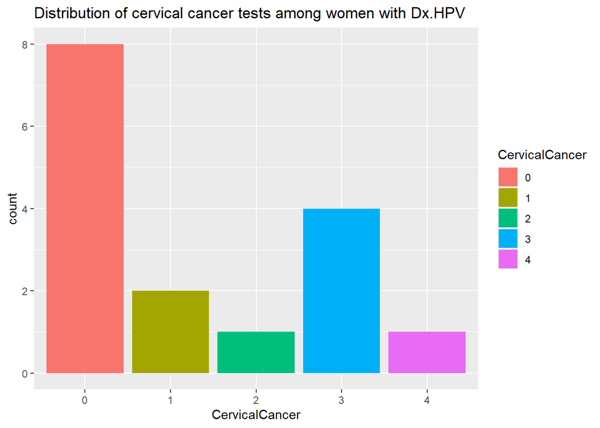

```r
cervicalCancerDataTmp = cervicalCancerData
cervicalCancerDataTmp$CervicalCancer = cervicalCancerData$Hinselmann + cervicalCancerData$Schiller + cervicalCancerData$Citology + cervicalCancerData$Biopsy
cervicalCancerDataTmp$CervicalCancer = factor(cervicalCancerDataTmp$CervicalCancer, levels=c("0","1","2","3","4"))
cervicalCancerDataTmp = subset(cervicalCancerDataTmp, select = -c(STDs..Time.since.last.diagnosis,STDs..Time.since.first.diagnosis))
COL_DATA = ncol(cervicalCancerDataTmp)
for (i in 1:COL_DATA) {
  cervicalCancerDataTmp[which(cervicalCancerDataTmp[,i] == "?"), i] = NA
}
cervicalCancerDataTmp = na.omit(cervicalCancerDataTmp)

cervicalCancerDataTmp$CervicalCancer = factor(cervicalCancerDataTmp$CervicalCancer, levels=c("0","1","2","3","4"))
# Sorting by number of positive test
cervicalCancerDataTmp <-cervicalCancerDataTmp[order(cervicalCancerDataTmp$CervicalCancer),]
# Sorting by smoking
cervicalCancerDataTmp <-cervicalCancerDataTmp[order(cervicalCancerDataTmp$IUD),]

# Mean of positive test- DX hpv
cervicalCancerDataDx.HPV <- cervicalCancerDataTmp %>%
  filter(between(Dx.HPV, 1, 1))

gDx.HPV <-ggplot(data = cervicalCancerDataDx.HPV) +
  geom_bar(mapping = aes(x = CervicalCancer, fill = CervicalCancer))
print((gDx.HPV + ggtitle("Distribution of cervical cancer tests among women with Dx.HPV")))
```

From the graphs shown above it can be seen that the risk of cervical cancer increases among women who have been diagnosed with HPV,In the supplemental we can see more graphs that indicates that the risk of cervical cancer increases among women with sexually transmitted diseases and women that smokes.

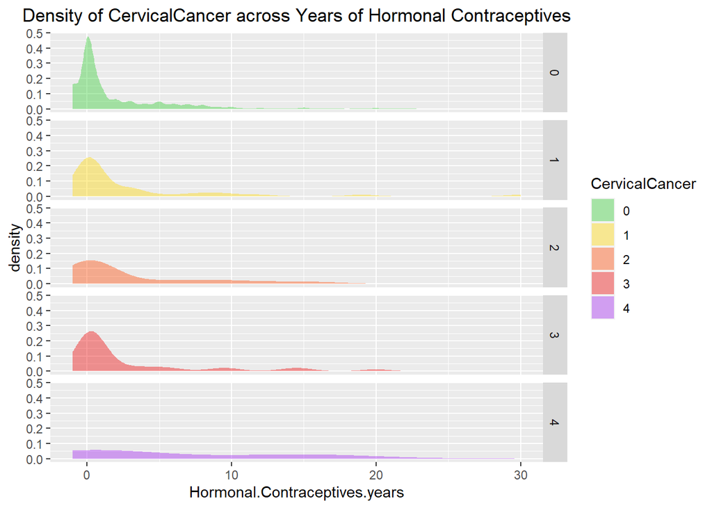

```r
newCervicalCancerData$CervicalCancer = factor(newCervicalCancerData$CervicalCancer, levels=c("0","1","2","3","4"))
# Check the proportion each value in the target
round(prop.table(table(newCervicalCancerData$CervicalCancer)),2)
```

```
##
##    0    1    2    3    4
## 0.88 0.05 0.03 0.04 0.01
```

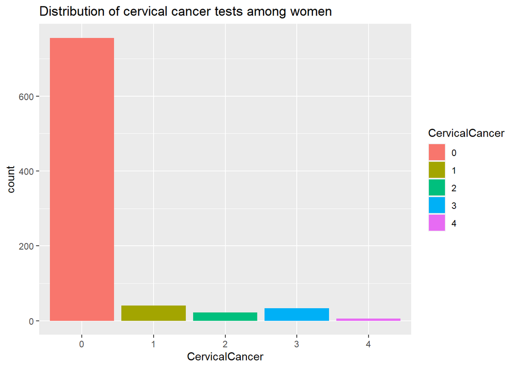

```r
# Plot the distribution of ages
gGeneral <- ggplot(data = newCervicalCancerData) +
  geom_bar(mapping = aes(x = CervicalCancer, fill = CervicalCancer))
print((gGeneral + ggtitle("Distribution of cervical cancer tests among women")))
```

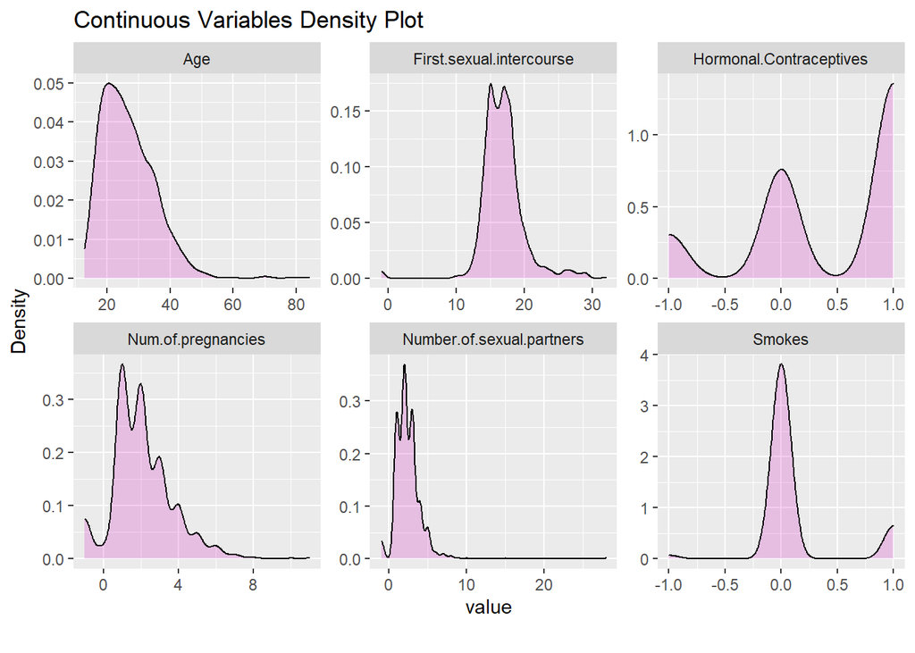

```r
plot_density(dplyr::select(newCervicalCancerData, c(Age, Number.of.sexual.partners,First.sexual.intercourse, Num.of.pregnancies, Hormonal.Contraceptives, Smokes )),  geom_density_args = list("fill" = 22, "alpha" = 0.2), title="Continuous Variables Density Plot", ncol=3)
```

From the first graph we can see the distribution of the rate of positive tests for cervical cancer in women The second graph shows the distribution of HPV risk factors: Age, First sexual intercourse, Hormonal contraceptives, number of pregnancies, number of sexual partners and smoking.

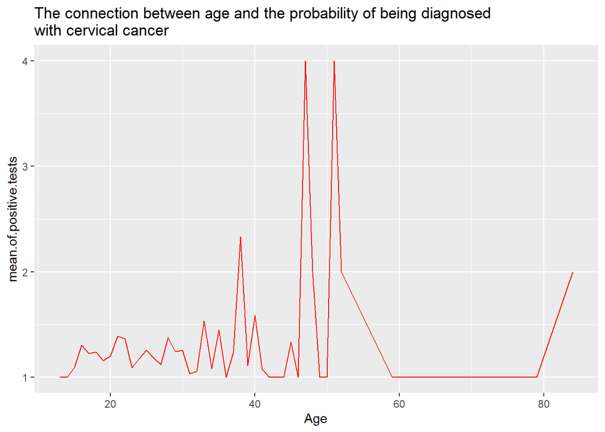

```r
newCervicalCancerData$CervicalCancer = as.numeric(newCervicalCancerData$CervicalCancer)
# Specify data column
new_table <- aggregate(x= newCervicalCancerData$CervicalCancer,

         # Specify group indicator
         by = list(newCervicalCancerData$Age),
         FUN = mean)

colnames(new_table)[1] <- "Age"
colnames(new_table)[2] <- "mean.of.positive.tests"
positiveTestG <- ggplot(data = new_table) +
  geom_line(mapping = aes(x = Age, y = mean.of.positive.tests), color="red")
print(positiveTestG + ggtitle("The connection between age and the probability of being diagnosed
with cervical cancer"))
```

It can be seen that Cervical cancer is mainly in the 35-55 age range.

In order to run the algorithms we performed further manipulations on our data.

```r
#Assign the values to yes or no potential for cancers
newCervicalCancerData$CervicalCancer = as.numeric(newCervicalCancerData$CervicalCancer)
newCervicalCancerData$CervicalCancer[newCervicalCancerData$CervicalCancer <2] <- 0
newCervicalCancerData$CervicalCancer[newCervicalCancerData$CervicalCancer >1] <- 1
```

## Algorithms:

## Kmeans Algorithm

K means is an algorithm of clusters made in the form of unsupervised. When we ran the algorithm we chose K to be equal to 2 because our target feature is binary. We’ll be using the kmeans() function.

```r
newCervicalCancerData$CervicalCancer = as.numeric(newCervicalCancerData$CervicalCancer)
interests <- newCervicalCancerData[1:33]
interests_z <- as.data.frame(lapply(interests, scale))
set.seed(2345)
cervicalCance_clusters <- kmeans(interests_z, 2)
newCervicalCancerData$cluster <- cervicalCance_clusters$cluster
aggregate(data = newCervicalCancerData, Dx.HPV ~ cluster, mean)
```

```
##   cluster     Dx.HPV
## 1       1 0.02390438
## 2       2 0.00000000
```

```r
aggregate(data = newCervicalCancerData, STDs.number ~ cluster, mean)
```

```
##   cluster STDs.number
## 1       1   0.1766268
## 2       2  -1.0000000
```

```r
aggregate(data = newCervicalCancerData, Smokes.years ~ cluster, mean)
```

```
##   cluster Smokes.years
## 1       1     1.197694
## 2       2     1.102866
```

```r
aggregate(data = newCervicalCancerData, Number.of.sexual.partners ~ cluster, mean)
```

```
##   cluster Number.of.sexual.partners
## 1       1                  2.463479
## 2       2                  2.114286
```

```r
aggregate(data = newCervicalCancerData, CervicalCancer ~ cluster, mean)
```

```
##   cluster CervicalCancer
## 1       1     0.12881806
## 2       2     0.04761905
```

So, from our clustering analysis we see that there is a connection between having STDS, HPV and smoking of women and the chance to have cervical cancer. It can be seen that in the first cluster there are women with HPV, STDs, smoking and a high number of sexual partners and accordingly in the first cluster there is a higher risk of cervical cancer. This could be very important information to researches.

## KNN Algorithm

The k-nearest neighbors algorithm (k-NN) is a non-parametric classification method. It is used for classification and regression. In both cases, the input consists of the k closest training examples in data set.

```r
newCervicalCancerData$CervicalCancer = factor(newCervicalCancerData$CervicalCancer, levels = c(0, 1))
set.seed(300)
# Create index to split based on labels
indxTrain <- createDataPartition(newCervicalCancerData$CervicalCancer, p=0.75, list=FALSE)
# Subset training set with index
training1 <- newCervicalCancerData[indxTrain,]
# Subset training set with index
testing1 <- newCervicalCancerData[-indxTrain,]

trainX <- training1[,names(training1) != "CervicalCancer"]
preProcValues <- preProcess(x = trainX,method = c("center", "scale"))
preProcValues
```

```
## Created from 644 samples and 37 variables
##
## Pre-processing:
##   - centered (37)
##   - ignored (0)
##   - scaled (37)
```

```r
set.seed(400)
ctrl <- trainControl(method="repeatedcv",repeats = 3)
knnFit <- train(CervicalCancer ~ ., data = training1, method = "knn", trControl = ctrl, preProcess = c("center","scale"), tuneLength = 20)

#Output of kNN fit
knnFit
```

```
## k-Nearest Neighbors
##
## 644 samples
##  37 predictor
##   2 classes: '0', '1'
##
## Pre-processing: centered (37), scaled (37)
## Resampling: Cross-Validated (10 fold, repeated 3 times)
## Summary of sample sizes: 580, 581, 579, 580, 580, 579, ...
## Resampling results across tuning parameters:
##
##   k   Accuracy   Kappa
##    5  0.9570255  0.7492682
##    7  0.9554790  0.7533417
##    9  0.9549501  0.7509564
##   11  0.9554469  0.7512641
##   13  0.9539005  0.7370070
##   15  0.9513038  0.7058616
##   17  0.9466481  0.6653843
##   19  0.9430183  0.6346672
##   21  0.9409590  0.6209319
##   23  0.9399091  0.6123717
##   25  0.9399008  0.6162346
##   27  0.9388671  0.6086183
##   29  0.9352451  0.5754331
##   31  0.9306054  0.5362420
##   33  0.9274964  0.5080485
##   35  0.9249243  0.4870123
##   37  0.9249163  0.4860602
##   39  0.9233698  0.4748862
##   41  0.9217991  0.4572684
##   43  0.9218071  0.4607613
##
## Accuracy was used to select the optimal model using the largest value.
## The final value used for the model was k = 5.
```

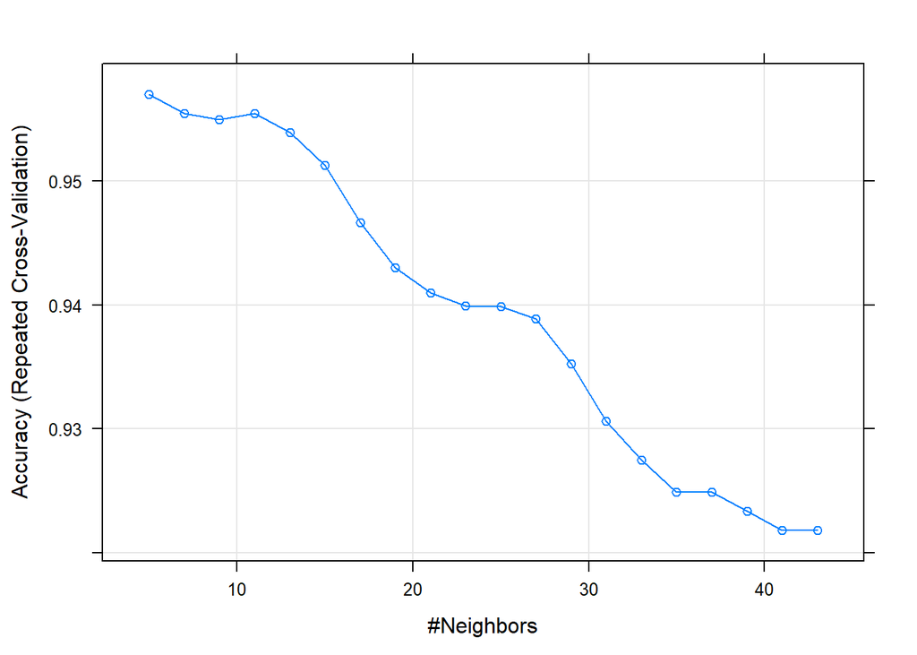

```r
plot(knnFit)
```

```r
# Predict the labels of the test set
knnPredictions<-predict.train(object=knnFit,testing1, type="raw")

# Evaluate the predictions
table(knnPredictions)
```

```
## knnPredictions
##   0   1
## 198  16
```

```r
confusionMatrix(knnPredictions,testing1$CervicalCancer)
```

```
## Confusion Matrix and Statistics
##
##           Reference
## Prediction   0   1
##          0 189   9
##          1   0  16
##
##                Accuracy : 0.9579
##                  95% CI : (0.9217, 0.9806)
##     No Information Rate : 0.8832
##     P-Value [Acc > NIR] : 0.0001125
##
##                   Kappa : 0.7585
##
##  Mcnemar's Test P-Value : 0.0076608
##
##             Sensitivity : 1.0000
##             Specificity : 0.6400
##          Pos Pred Value : 0.9545
##          Neg Pred Value : 1.0000
##              Prevalence : 0.8832
##          Detection Rate : 0.8832
##    Detection Prevalence : 0.9252
##       Balanced Accuracy : 0.8200
##
##        'Positive' Class : 0
##
```

As it can see above, We looked for a different K each time and saw that in all the options the classification was high but after comparison, we chose k=5 because it give us the best accuracy.

Let’s split our data to train and test, relevant for the 3 following algorithms:

```r
set.seed(12345)
#Now, we dont need anymore these four column. Let's delete them.
newCervicalCancerData <- newCervicalCancerData[ -c(33:36) ]
split = sample.split(newCervicalCancerData$CervicalCancer, SplitRatio = 0.75)
training_set = subset(newCervicalCancerData, split == TRUE)
test_set = subset(newCervicalCancerData, split == FALSE)
# Feature Scaling
training_set[-33] = scale(training_set[-33])
test_set[-33] = scale(test_set[-33])
```

## Decision Tree Algorithm

A decision tree is a decision support tool that uses a tree-like model of decisions and their possible consequences, including chance event outcomes, resource costs, and utility. It is one way to display an algorithm that only contains conditional control statements.

In order to build decision trees, we are actually building questions that help us catalog the information. The decision trees are built so that they start from the tree root and separate the data with the help of the feature that gives us the most information gain. We repeat the process in each split until pure leaves are obtained, meaning that all the samples in them are from the same class.

```r
library("rpart.plot")
set.seed(1234341)
classifierDecisionTree = rpart(formula = CervicalCancer  ~ .,
                   data = training_set)
y_predDecisionTree = predict(classifierDecisionTree, newdata = test_set[-33], type = 'class')
confusionMatrix(test_set[, 33], y_predDecisionTree)
```

```
## Confusion Matrix and Statistics
##
##           Reference
## Prediction   0   1
##          0 188   1
##          1  26   0
##
##                Accuracy : 0.8744
##                  95% CI : (0.8226, 0.9156)
##     No Information Rate : 0.9953
##     P-Value [Acc > NIR] : 1
##
##                   Kappa : -0.009
##
##  Mcnemar's Test P-Value : 3.86e-06
##
##             Sensitivity : 0.8785
##             Specificity : 0.0000
##          Pos Pred Value : 0.9947
##          Neg Pred Value : 0.0000
##              Prevalence : 0.9953
##          Detection Rate : 0.8744
##    Detection Prevalence : 0.8791
##       Balanced Accuracy : 0.4393
##
##        'Positive' Class : 0
##
```

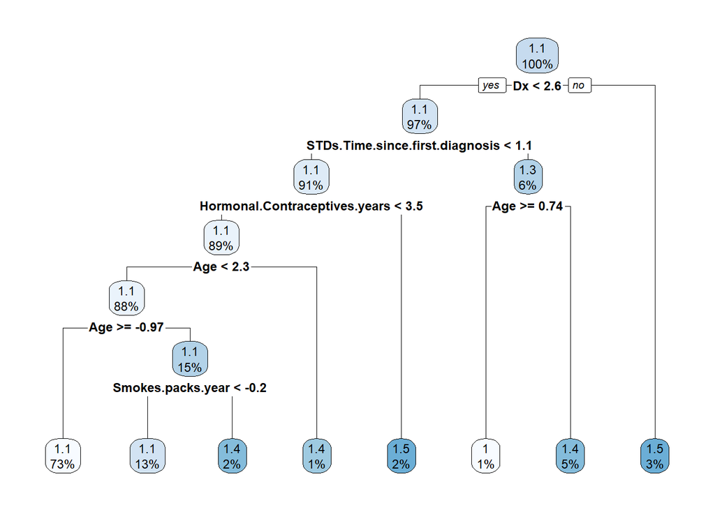

```r
regressionTree3Complex <- rpart(CervicalCancer ~ . , data = training_set, method = "anova", cp = 0.01)
rpart.plot(regressionTree3Complex)
```

## Random Forest Algorithm

Random forests or random decision forests are an ensemble learning method for classification, regression and other tasks that operates by constructing a multitude of decision trees at training time. For classification tasks, the output of the random forest is the class selected by most trees.

```r
set.seed(12389)
classifierRandomForest = randomForest(x = training_set[-33],
                          y = training_set$CervicalCancer,
                          ntree = 500)
y_predRandomForest = predict(classifierRandomForest, newdata = test_set[-33], type = 'class')
confusionMatrix(test_set[, 33], y_predRandomForest)
```

```
## Confusion Matrix and Statistics
##
##           Reference
## Prediction   0   1
##          0 187   2
##          1  25   1
##
##                Accuracy : 0.8744
##                  95% CI : (0.8226, 0.9156)
##     No Information Rate : 0.986
##     P-Value [Acc > NIR] : 1
##
##                   Kappa : 0.0451
##
##  Mcnemar's Test P-Value : 2.297e-05
##
##             Sensitivity : 0.88208
##             Specificity : 0.33333
##          Pos Pred Value : 0.98942
##          Neg Pred Value : 0.03846
##              Prevalence : 0.98605
##          Detection Rate : 0.86977
##    Detection Prevalence : 0.87907
##       Balanced Accuracy : 0.60770
##
##        'Positive' Class : 0
##
```

## SVM Algorithm

SVM is a machine learning algorithm that can be used to analyze data for classification or regression problems. He uses a technique called the kernel trick. SVM’s algorithm only works on numeric variables, so our data is definitely excellent data for using this type of algorithm.

```r
set.seed(123812)
classifierSVM = svm(formula = CervicalCancer ~ .,
                 data = training_set,
                 type = 'C-classification',
                 kernel = 'linear')
y_predSVM = predict(classifierSVM, newdata = test_set[-33])
confusionMatrix(test_set[, 33], y_predSVM)
```

```
## Confusion Matrix and Statistics
##
##           Reference
## Prediction   0   1
##          0 187   2
##          1  25   1
##
##                Accuracy : 0.8744
##                  95% CI : (0.8226, 0.9156)
##     No Information Rate : 0.986
##     P-Value [Acc > NIR] : 1
##
##                   Kappa : 0.0451
##
##  Mcnemar's Test P-Value : 2.297e-05
##
##             Sensitivity : 0.88208
##             Specificity : 0.33333
##          Pos Pred Value : 0.98942
##          Neg Pred Value : 0.03846
##              Prevalence : 0.98605
##          Detection Rate : 0.86977
##    Detection Prevalence : 0.87907
##       Balanced Accuracy : 0.60770
##
##        'Positive' Class : 0
##
```

## Adaboost Algorithm

Boosting is an ensemble technique that attempts to create a strong classifier from a number of weak classifiers.

```r
# Create index to split based on labels
indxTrain2 <- createDataPartition(newCervicalCancerData$CervicalCancer, p=0.75, list=FALSE)
# Subset training set with index
training2 <- newCervicalCancerData[indxTrain2,]
# Subset training set with index
testing2 <- newCervicalCancerData[-indxTrain2,]
model = boosting(CervicalCancer ~ ., data=training2, boos=TRUE, mfinal=50)
print(names(model))
```

```
## [1] "formula"    "trees"      "weights"    "votes"      "prob"
## [6] "class"      "importance" "terms"      "call"
```

```r
#print(model$trees[1])
pred = predict(model, testing2)
print(pred$confusion)
```

```
##                Observed Class
## Predicted Class   0   1
##               0 183  21
##               1   6   4
```

```r
print(1 - pred$error)
```

```
## [1] 0.8738318
```

```r
result = data.frame(testing2$CervicalCancer, pred$prob, pred$class)
#print(result)
```

## LDA Algorithm

Linear Discriminant Analysis (LDA) is a statistical method that can be used both for dimensionality reduction (Similar to PCA, tSNE and UMAP) and for classification (like linear regression, for example).

LDA works on continuous variables, and is considered a supervised method.

```r
set.seed(123)
ind <- sample(2, nrow(newCervicalCancerData),
              replace = TRUE,
              prob = c(0.7, 0.3))
training <- newCervicalCancerData[ind==1,]
testing <- newCervicalCancerData[ind==2,]
linear <- lda(CervicalCancer~., training)
#linear
attributes(linear)
```

```
## $names
##  [1] "prior"   "counts"  "means"   "scaling" "lev"     "svd"     "N"
##  [8] "call"    "terms"   "xlevels"
##
## $class
## [1] "lda"
```

```r
p1 <- predict(linear, training)$class
tab <- table(Predicted = p1, Actual = training$CervicalCancer)
tab
```

```
##          Actual
## Predicted   0   1
##         0 509  59
##         1  16  19
```

```r
p2 <- predict(linear, testing)$class
tab1 <- table(Predicted = p2, Actual = testing$CervicalCancer)
tab1
```

```
##          Actual
## Predicted   0   1
##         0 220  20
##         1  11   4
```

```r
sum(diag(tab1))/sum(tab1)
```

```
## [1] 0.8784314
```

## Dimensionality reduction - PCA/tSNE/LDA

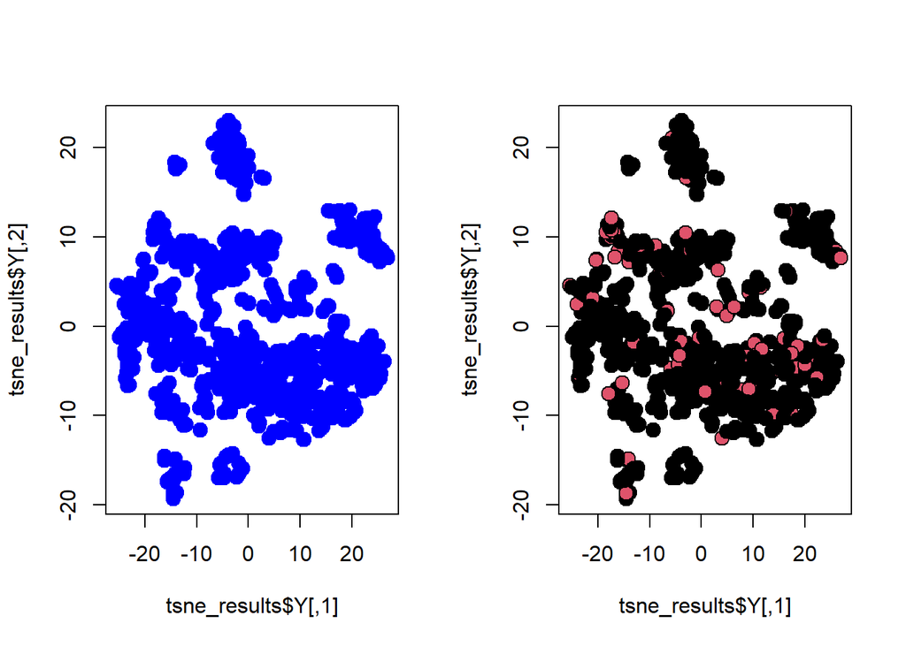

```r
newCervicalCancerData$CervicalCancer = factor(newCervicalCancerData$CervicalCancer, levels = c(0, 1))
## Split the data into two objects.
IR_data <- newCervicalCancerData[ ,1:32] # We are sub-setting IR object such as to include 'all rows' and columns 1 to 4.
IR_species <- newCervicalCancerData[ ,33] # We are sub-setting IR object such as to include 'all rows' and column 5.

## Run the t-SNE algorithm and store the results into an object called tsne_results
tsne_results <- Rtsne(IR_data, perplexity=30, check_duplicates = FALSE) # You can change the value of perplexity and see how the plot changes

## Generate the t_SNE plot
par(mfrow=c(1,2)) # To plot two images side-by-side
plot(tsne_results$Y, col = "blue", pch = 19, cex = 1.5) # Plotting the first image
plot(tsne_results$Y, col = "black", bg= IR_species, pch = 21, cex = 1.5) # Second plot: Color the
```